# Statistical Learning, Homework-01

Barba Paolo, Candi Matteo, Costantini Silvia, Vestini Maria Vittoria

2023-05-10

```r
rm(list = ls())

# Set reproducibility -----------------------------------------------------
seed <- 1234
set.seed(seed)

# Libraries and Data ---------------------------------------------------------------

pkt <- c('glmnet', 'NMOF', 'parallel', 'snow', 'ggplot2', 'reshape2', 'gridExtra','tidyverse')

invisible(lapply(pkt, require, character.only = TRUE))
```

## Purpose & Statistical tools used

The homework’s goal is to try to estimate an unknown function $f(X)$ in order to predict the response variable $Y$ from independent data $(X_1,Y_1) \dots ,(X_n,Y_n)$, to achieve this goal we will assume:

- $Y_i | X_1 , \dots , X_n \sim p(y | f(X_i))$
- $f$ lies in some fixed class of functions.

For the Homework’s sake we are going to use a penalized linear regression model and truncated power basis function, obtaining the following:
$$Y_i = f(\underline{x_i}) +
\epsilon_i \ for \ i = 1\dots n$$
where the $\epsilon_i$ are $i.i.d$ data from some normal distribution $N(0,\sigma^2)$.

In order to get the optimal hyperparameters and MSE estimation we will implement CV and nested CV techniques.

## Be linear in transformed feature space

The basic idea of being linear in a transformed feature space is to map our parameters into a higher dimensional space with d-dimensions. The model will then be linear in that space.

Let $\phi(x)$ be a feature mapping function that maps the input data $x$ into a transformed d-dimensional space. Let $w$ be a weight vector in the transformed space. Thus, the prediction function is given by $f(x) = w^T\phi(x)$. By mapping the parameters into higher dimensional space, we can capture more complex structures between the features and the target variable.

The polynomial models in a d-dimensional feature space assume that there is a fixed functional form for the relationship between features and the response variable. And since this relationship is defined globally, these models may not capture the entire complexity of the data.

Spline regression models, instead, provide more flexible and adaptive modeling in order to catch up the local structures of the target variable $Y$.

In order to implement splines, we use truncated power functions $\mathcal{G}_{d,q}$, defined as:

$$\mathcal{G}_{d,q} = \{g_1(x) \dots
g_{d+1}(x),g_{(d+1)+1}(x),\dots,g_{(d+1)+q}(x) \}$$
where:

$\{g_1(x)=1,g_2(x)=x,...,g_{d+1}(x)=x^{d}\}$ and $\{g_{(d+1)+j}(x)= (x−\xi_{j})^d_+\}$ where $(x)_+ =max\{0,x\}$.

It can be easily shown that the spline function $f(x)$ can be represented by a linear combination of the power functions $\mathcal{G}_{d,q}$:

$$f(x)= \sum_{j= 1}^{d+q+1} β_j
·g_j(x)$$

where $\beta_j$ are the coefficients to be estimated, and $g_j(x)$ denotes the $j$-th power function of $\mathcal{G}_{d,q}$.

## Implementation of the truncated power basis

We have developed our own function of the truncated power basis $\mathcal{G}_{d,q}$. This function takes as input the degree $d$ of the truncated power functions, the number of knots $q$, and their positions, and returns a feature matrix $\mathbb{X}$. The feature matrix $\mathbb{X}$ will be used to obtain a prediction of the response variable $Y$.

In order to illustrate our implementation, in the following plots, results are shown considering $d\ \in \{1 , 3\}$ and $q\ \in \{3 , 10\}$.

```r
# Function used to compute the feature matrix
power_functions <- function(d, q, knots, x){
  X <- matrix(NA, length(x), d+q+1)  # Pre-set the feature matrix
  for( i in 1:length(x)){            # Loop over the data-points

    for( j in 1:(d+q+1) ){           # Loop over the basis used

      if ( j <= d+1 ){               # Check if the index belong to the firsts (d+1) indices
        X[i,j] <- x[i]^(j-1)         # Compute the powers
      }

      else                           # The index do not belong to the firsts (d+1) indices
        if((x[i] - knots[j-(d+1)])^d > 0){      # Check if the power of the difference between the data-point and the knot is positive
          X[i,j] <- (x[i] - knots[j-(d+1)])^d   # Compute the power of the difference
        }
      else                           # the power is not positive
         X[i,j] <- 0                 # Set the value to 0
    }
  }
  return(X)                         # Return the feature matrix
}
```

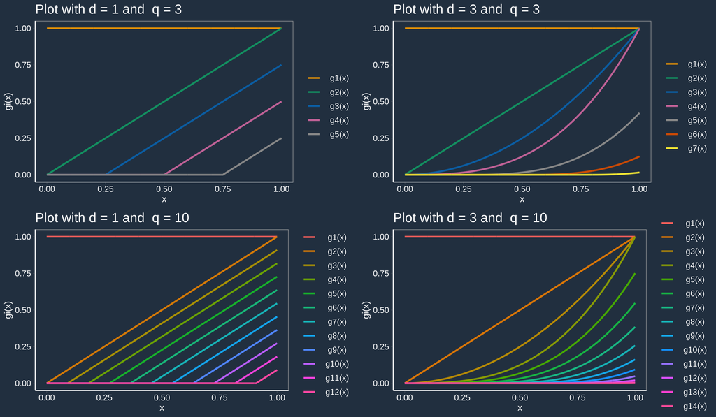

## Comments

For $j \le d +1$, the truncated power function is defined as $g_j(x) = x^{j-1}$. For $j > d +1$, the truncated power function is defined as $g_j(x) = (x-\xi_j)^d_+$, where $(x)_+ = \max\{0,x\}$, and $\xi_j$ is the $(j-d-1)$-th knot.

For $j > d +1$, the truncated power function is equal to zero for data points below the knot $\xi_j$, and $(x-\xi_j)^d$ for data points above the knot.

The use of truncated power basis allows us to work with a higher dimensional feature space without using a high degree polynomial. The additional dimensions in the feature space come from the truncated power functions that capture the local structure of the target function around each knot. This can lead to more accurate modeling of complex relationships between the input features and the target variable.

## ChatGPT - Power function

In this section we ask CHAT-GPT to implement its own version of truncated power basis. Below are reported the conversation we had with it.

**1° Request:**

” Can you implement a function in R to compute the truncated power basis, with parameters $d$, $q$, knots. Where $g_i=x^{i-1}$ if $i\le(d+1)$ else $g_{d+1+j} = \max((x-knots[j])^d, 0)$ for $j \in [1,q]$? ”

**1 ° Response:**

” Certainly! Here’s a function in R that computes the truncated power basis you described:

```r
truncated_power_basis <- function(x, d, q, knots) {

  # Compute the first d+1 basis functions
  basis <- matrix(0, nrow = length(x), ncol = d+1)
  basis[,1] <- 1
  for (i in 2:(d+1)) {
    basis[,i] <- x^(i-1)
  }

  # Compute the remaining basis functions using knots
  for (j in 1:q) {
    basis[,d+1+j] <- pmax((x - knots[j])^d, 0)
  }

  return(basis)
}
```

This function takes as input the vector $x$, the integer $d$, the integer $q$, and the vector knots. It returns a matrix with length(x) rows and $d+1+q$ columns, where each column represents a basis function.”

Let’s give a try to the ChatBot implementation!

```r
d <- 1
q <- 3
knots <- seq(0, 1, length.out=q)
x <- seq(0, 1, length.out=1000)

M <- truncated_power_basis(x, d, q, knots)
```

```
## Error in `[<-`(`*tmp*`, , d + 1 + j, value = pmax((x - knots[j])^d, 0)): subscript fuori limite
```

Oopsie Doopsie! Looks like the ChatBot response doesn’t work. So we will try and see how much we have to tell it in order to obtain a working function, the first thing we will do is show it the error we got.

*For this following part the code will not be directly shown.*

**2° message request:**

” It seems like there is an error with your function, if i try to use it I get this error: “Error in `[<-`(`*tmp*`, , d + 1 + j, value = pmax((x - knots[j])^d, 0)): subscript out of bounds”. Could you give me the correct implementation? ”

**2° response:**

” I apologize for the error in my previous implementation. Here’s an updated version of the truncated_power_basis function that should work correctly:

```r
truncated_power_basis <- function(x, d, q, knots) {
  # Compute the first d+1 basis functions
  basis <- matrix(0, nrow = length(x), ncol = d+1)
  basis[,1] <- 1
  for (i in 2:(d+1)) {
    basis[,i] <- x^(i-1)
  }

  # Compute the remaining basis functions using knots
  if (q > 0) {
    for (j in 1:q) {
      basis[,d+j+1] <- pmax((x - knots[j])^d, 0)
    }
  }

  return(basis)
}
```

… ”

Again it doesn’t work, so this time we give the ChatBot a hint, since we realize that the problem is that there isn’t enough allocated space for the matrix, in fact the matrix should have $q+d+1$ columns instead of $d+1$.

**3° message:**

” It doesn’t solve it, I think the problem is in the dimension of the matrix. ”

**3° response:**

” I apologize for the continued issue. You are correct that there is an issue with the dimension of the matrix. Here is the corrected implementation of the truncated_power_basis function:

```r
truncated_power_basis <- function(x, d, q, knots) {
  # Compute the first d+1 basis functions
  basis <- matrix(0, nrow = length(x), ncol = d+1)
  basis[,1] <- 1
  for (i in 2:(d+1)) {
    basis[,i] <- x^(i-1)
  }

  # Compute the remaining basis functions using knots
  if (q > 0) {
    for (j in 1:q) {
      basis[,d+j+1] <- pmax((x - knots[j])^(d*(x >= knots[j])), 0)
    }
  }

  return(basis)
}
```

… ”

At the end since also this implementation doesn’t work we decided to tell the ChatBot how to solve the issue.

**4° message:**

” Still not good, shouldn’t the matrix have $q+d+1$ columns since we are trying to evaluate $q+d+1$ functions? “😅

**4° response:**

” You are correct. I apologize for the error. The matrix should have $q + d + 1$ columns since we are computing a total of $q + d + 1$ basis functions. Here is the corrected implementation:

```r
truncated_power_basis <- function(x, d, q, knots) {
  # Compute the first d+1 basis functions
  basis <- matrix(0, nrow = length(x), ncol = d+1)
  basis[,1] <- 1
  for (i in 2:(d+1)) {
    basis[,i] <- x^(i-1)
  }

  # Compute the remaining basis functions using knots
  if (q > 0) {
    for (j in 1:q) {
      basis[,d+j+1] <- pmax((x - knots[j])^(d*(x >= knots[j])), 0)
    }
  }

  return(basis)
}
```

… ”

But again even if we straight up told the Bot what’s the problem and how to solve it the function is not working! At the end the only thing left to do is just tell it the code it should use.

**5° (and final) message:**

” You are not allocating the memory for the matrix correctly, basis should be defined as “basis <- matrix(0, nrow = length(x), ncol = d+q+1)”. ”

**5° response:**

” You are correct again. I apologize for the confusion. Here is the corrected implementation:

```r
truncated_power_basis <- function(x, d, q, knots) {
  # Compute the first d+1 basis functions
  basis <- matrix(0, nrow = length(x), ncol = d+q+1)
  basis[,1] <- 1
  for (i in 2:(d+1)) {
    basis[,i] <- x^(i-1)
  }

  # Compute the remaining basis functions using knots
  if (q > 0) {
    for (j in 1:q) {
      basis[,d+j+1] <- pmax((x - knots[j])^(d*(x >= knots[j])), 0)
    }
  }
  ?pmax
  return(basis)
}
```

$\dots$ ”

Finally we obtain a function without errors!

```r
truncated_power_basis(seq(0,1,length.out=6), 3, 2, c(0.1, 0.5))
```

```
##      [,1] [,2] [,3]  [,4]  [,5]  [,6]
## [1,]    1  0.0 0.00 0.000 1.000 1.000
## [2,]    1  0.2 0.04 0.008 0.001 1.000
## [3,]    1  0.4 0.16 0.064 0.027 1.000
## [4,]    1  0.6 0.36 0.216 0.125 0.001
## [5,]    1  0.8 0.64 0.512 0.343 0.027
## [6,]    1  1.0 1.00 1.000 0.729 0.125
```

Sadly though we realize that, from the third response on, the ChatBot changed a line of code from $basis[,d+j+1] <- pmax((x - knots[j])^d, 0)$ to $basis[,d+j+1] <- pmax((x - knots[j])^{d*(x >= knots[j])}, 0)$ and now the function indeed does gives an output, but it’s not the right one.

## Comments:

After the chat we had with ChatGPT, our thoughts are that the chatbot can be very useful for providing a starting point. We believe, however, that can be risky for non-experts in the field to use the chatbot, since they may not be able to identify errors or misunderstandings in the information that the chat provides.

We have to remark that chatbots have limitations in fields that require specialized knowledge or experience, such as statistics or data analysis.😉

## Dataset

The Dataset we are going to use to implement the model is about **Wilkinson Microwave Anisotropy Probe**, also known as **WMAP**. An explorer mission that measured the difference of temperature across the space.

The Dataset is composed by $675$ observations of $2$ variable of interest.

```r
test_set_vero <- read.csv("test.csv")
train_set <- read.csv("train.csv")
```

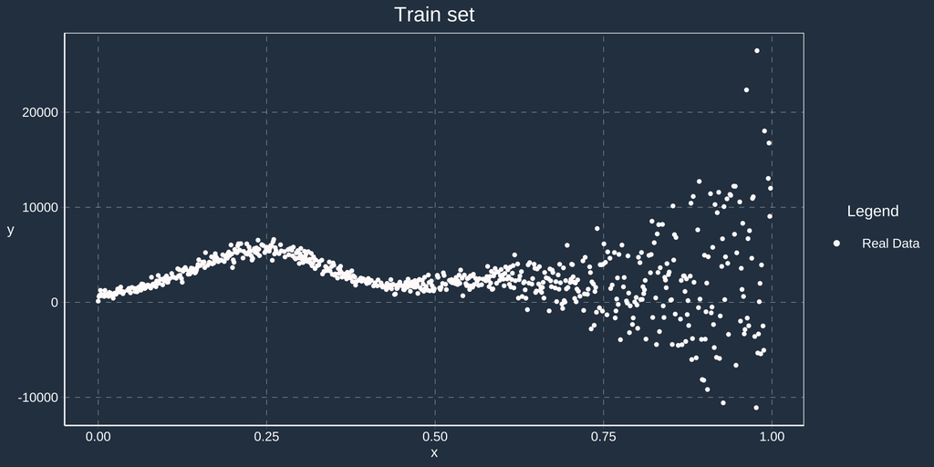

## Vanilla Cross Validation

In order to estimate the coefficients $\beta_j$ in our penalized linear model, we are going to perform a *k-fold* cross validation.

Since the variance of the response variable is not constant across the range of predictor variables it can be possible that, picking knots where the functions is very variable, may influence the good predictive performance of our model. In order to try to resolve this problem, we fix the lower bound of the position of the knots at $0$ and we add the hyperparameter $p$ that is representing the upper bound. The knots will be equispaced in interval $(0,p]$.

Once we have performed the power functions, we train a penalized linear model, where we tune the type of regularization from Ridge to Lasso throughout some elastic net.

At the end of the day, we end up with $5$ hyperparameter to tune:

- $\alpha$ for Ridge, Lasso and elastic net
- $\lambda$ Regularization parameter
- $d$ degree of the power functions
- $q$ the number of knots
- $p$ positions of the upper bound

We will down-weight observations with high variance and up-weight observations with low variance, which can decrease the error of our predictions.

Given the knots we estimated the conditional variance by computing the empirical variance of $y$ in the intervals defined by the knots.

The idea is that after cross validation we shrink the space of our parameters that we consider sub-optimal. Then we will perform the nested cross validation in order to select in a more accurate way the hyperparameters.

```r
# Function to estimate the weights
compute_weights <- function(knots , dataset){
  # Number of knots
  n <- length(knots)
  # Add the bounds
  knots <- c(0, knots)
  if(knots[n+1] != 1){
    knots <- c(knots, 1)
  }

  # Define the matrix
  xx <- rep(NA, length(dataset$x))
  # Intialize v in case there are no data-points in the first interval
  v <- 1

  # For each interval bounded by the knots
  for(i in 1:(n+1)){
    # Check if there are at least 2 data points inside the interval
    if(sum(dataset$x >= knots[i] & dataset$x <= knots[i+1])>1){
      # Compute the conditional variance
      v  <- var(dataset$y[(dataset$x >= knots[i]) & (dataset$x <= knots[i+1])])
      # Set the weight of the data points equal to the inverse of the variance
      xx[dataset$x >= knots[i] & dataset$x <= knots[i+1]] <- 1/v
    }
    # If there is only one data point
    else if(sum(dataset$x >= knots[i] & dataset$x <= knots[i+1]) == 1){
      # Since we can't compute the variance of a single data point then we use the previously computed variance
      xx[dataset$x >= knots[i] & dataset$x <= knots[i+1]] <- 1/v
    }
  }

  return(xx)
}


# Function used for the cross validation
cross_val_func <- function(x){
  set.seed(070720)
  # Define the parameters
  d <- x[1]
  q <- x[2]
  k <- x[3]
  a <- x[4]
  l <- x[5]
  p <- x[6]

  # size of the fold
  l_folds <- nrow(train_set) / k
  # Pre-set the scores (MSE)
  score <- rep(NA, k)
  # Random  sample of the indices
  idx <- sample((1:nrow(train_set)),nrow(train_set))
  #Loop over the folds
  for ( i in 1:k){
    # Set the validation and train set
    cv_test <- train_set[idx[((i-1)*l_folds+1): (i*l_folds)],]
    cv_train <- train_set[-idx[((i-1)*l_folds+1): (i*l_folds)],]

    # Conpute the knots
    knots <- seq(0, p, length.out=q+1)[2:(q+1)]

    # Compute the power function on the training set
    M_cv_train <- power_functions(d = d, q = q, knots = knots, x = cv_train$x)

    # Compute the power function on the valifation set
    M_cv_test <-  power_functions(d = d, q = q, knots = knots, x = cv_test$x)

    # compute the weights, based on the conditional variance
    hat_weights <- compute_weights(knots = knots , cv_train)

    # Train the model
    cv_model <- glmnet(M_cv_train,
                       cv_train$y,
                       family = "gaussian",
                       alpha=a,
                       lambda=l,
                       weights = hat_weights)

    # Preditcion on the validation set
    cv_predictions <- predict(cv_model, M_cv_test)

    # Compute the score
    score[i] <- sqrt(mean((cv_test$y-cv_predictions)^2))

  }
  # Return the mean MSE
  return(mean(score))
}
```

```r
# parameters
k <- c(5)
d_grid <- c(1, 3)
q_grid <- seq(3, 50, 2)
positions <- seq(0.2, 0.8, 0.1)
lambdas <- 10^seq(-0.5, 0, .05)
alphas <- seq(0, 1, 0.1)
# Set the parameter for the CV
parameters <- list(d_grid, q_grid, k, alphas, lambdas, positions)

# CV vanilla --------------------------------------------------------------
# Select the best combination of parameters
cl = makeCluster(detectCores())
clusterExport(cl, c('train_set', 'power_functions', 'glmnet', 'compute_weights'))
res <- gridSearch(cross_val_func, levels=parameters, method = 'snow', cl=cl)
stopCluster(cl)
best_params <- res$minlevels
names(best_params) <- c('d', 'q', 'k', 'alpha', 'lambda', 'position')
```

After the vanilla cross validation this are the hyperparameters we obtained:

```r
load("RData//best_params_vanilla_NODC.RData")

# Prediction --------------------------------------------------------------

# Using the best parameters
d_best <- best_params[1]
q_best <- best_params[2]
k_best <- best_params[3]
a_best <- best_params[4]
l_best <- best_params[5]
p_best <- best_params[6]

# Compute the predictions
knots <- seq(0, p_best, length.out=q_best+1)[2:(q_best+1)]
M_train <- power_functions(d = d_best, q = q_best, knots = knots, x = train_set$x)
M_test <- power_functions( d = d_best, q = q_best, knots = knots, x = test_set_vero$x)
knots_test <- power_functions( d = d_best, q = q_best, knots = knots, x = knots)
hat_weights <- compute_weights(knots , train_set)
final_model <- glmnet(M_train, train_set$y, family ="gaussian",
                      alpha=a_best, lambda=l_best , weights = hat_weights )
predictions <- predict(final_model,M_test)
round(best_params,3)
```

[output not shown]

After training the model with those hyperparameters and predicting the $Y$ in the test set, we can plot our results.

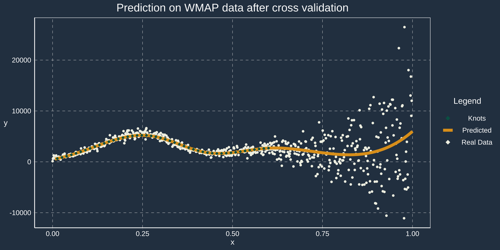

### Kaggle-LeaderBoard-Result: 3329.84561 in RMSE

## Update the parameters

As anticipated before, after computing the *k-fold* cross validation, we are going to select some new parameter, similar to the ones obtained from the validation, to be tuned via Nested Cross Validation.

```r
# Update Parameters -------------------------------------------------------------

# Using the best parameters
d_best <- best_params[1]
q_best <- best_params[2]
k_best <- best_params[3]
a_best <- best_params[4]
l_best <- best_params[5]
p_best <- best_params[6]

#Select the new parameters for the nested cross validation
d <- d_best
q <- q_best+seq(-2,2,1)
k <- k_best
a <- a_best + seq(-0.03, 0, 0.01)
l <- l_best + seq(-0.05, 0.05, 0.025)
p <- p_best

# Set the parameter for the CV
parameters <- list(d, q, k, a, l, p)
```